# Assignment 7

Jen LaDuke

2024-11-04

## R Markdown

1. Make a plot using facet_wrap by one categorical variable (facet_wrap(~variable1))

```r
library(tidyverse)
library(knitr)
```

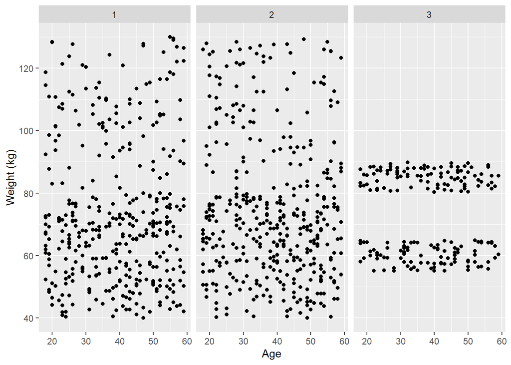

```r
library(ggplot2)
df = read_csv('gym_members_exercise_tracking.csv')
df <- df %>%
    mutate(`Weight (kg)` = as.numeric(`Weight (kg)`))
df %>%
    ggplot() +
    geom_point(mapping = aes(x = Age, y = `Weight (kg)`)) +
    facet_wrap(~Experience_Level)
```

### Experience 1 and 2 has a lot of variety in weights, while level 3, the experts, have a smaller range. More experienced individuals may have reached plateaus in their weight, leading to less variability. This can happen as they become more specialized in their training.

2. Make a plot using facet_wrap by two categorical variables (facet_wrap(~variable1+variable2))

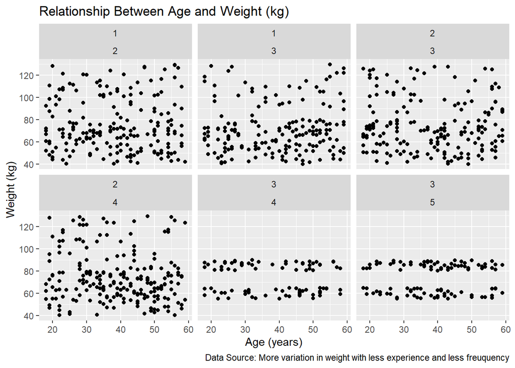

```r
df <- df %>%
  mutate(`Workout_Frequency (days/week)` = as.character(`Workout_Frequency (days/week)`))
df %>%
    ggplot() +
    geom_point(mapping = aes(x = Age, y = `Weight (kg)`)) +
    facet_wrap(~Experience_Level + `Workout_Frequency (days/week)`) +
    labs(
        title = "Relationship Between Age and Weight (kg)",
        x = "Age (years)",
        y = "Weight (kg)",
        caption = "Data Source: More variation in weight with less experience and less freuquency"
    )
```

3. Make a plot using position =‘dodge’.

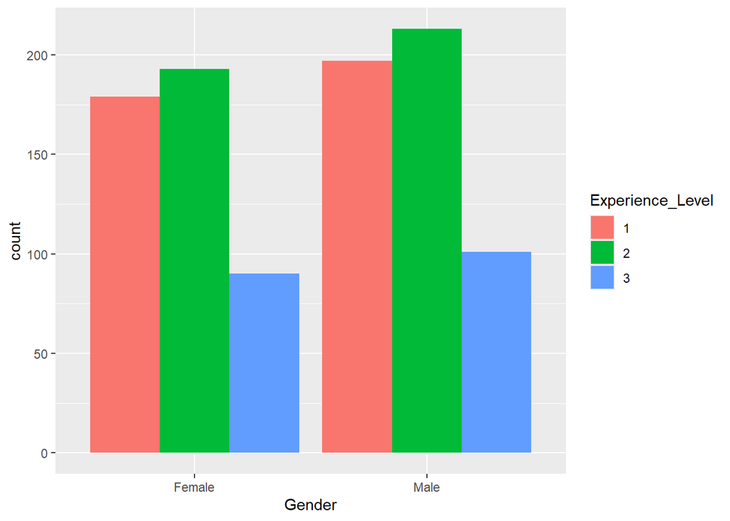

```r
df <- df %>%
    mutate(`Experience_Level` = as.character(`Experience_Level`))
df %>%
  ggplot()+
    geom_bar(mapping=aes(x= Gender, fill=Experience_Level),
             position = 'dodge')
```

```r
 labs(
        title = "Distribution of Experience Levels by Gender",
        x = "Gender",
        y = "Count",
        fill = "Experience Level",
        caption = "Data Source: More people are experience level 1 or 2"
    )
```

```
## $x
## [1] "Gender"
##
## $y
## [1] "Count"
##
## $fill
## [1] "Experience Level"
##
## $title
## [1] "Distribution of Experience Levels by Gender"
##
## $caption
## [1] "Data Source: More people are experience level 1 or 2"
##
## attr(,"class")
## [1] "labels"
```

### The plot indicates that both females and males are predominantly represented at experience level 2, with a slightly higher number of males. This trend may suggest that experience level 2 is the most common stage of engagement in the activities measured, possibly reflecting a threshold where individuals feel comfortable and competent.

4. Make a plot using position =‘fill’.

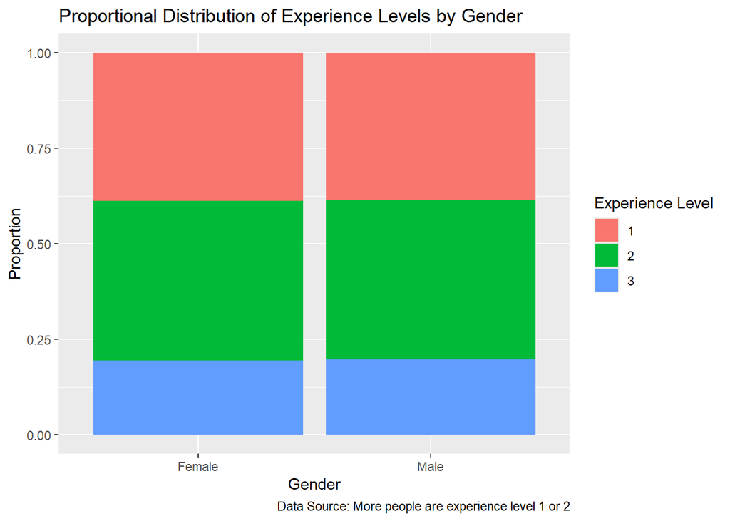

```r
df %>%
  ggplot() +
  geom_bar(mapping = aes(x = Gender, fill = Experience_Level),
           position = 'fill') +
  labs(
    title = "Proportional Distribution of Experience Levels by Gender",
    x = "Gender",
    y = "Proportion",
    fill = "Experience Level",
    caption = "Data Source: More people are experience level 1 or 2"
  )
```

### Each bar represents 100% of the individuals in that gender, with different colors indicating the proportion of each experience level.

5. Make a plot using geom_col.

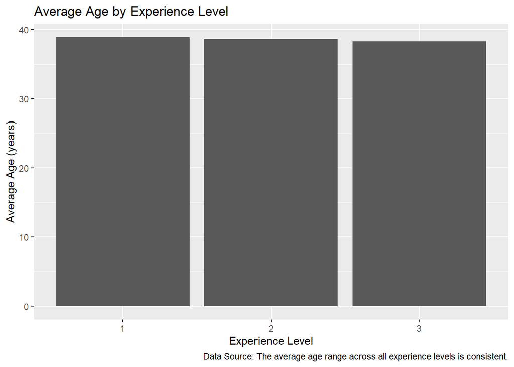

```r
df %>%
  group_by(Experience_Level) %>%
  summarise(average_age = mean(Age, na.rm = TRUE)) %>%
  ggplot() +
    geom_col(mapping = aes(x = Experience_Level, y = average_age)) +
    labs(
        title = "Average Age by Experience Level",
        x = "Experience Level",
        y = "Average Age (years)",
        caption = "Data Source: The average age range across all experience levels is consistent."
    )
```

### The bar plot indicates that there is little to no variation in average age across the different experience levels, suggesting that individuals of various ages are participating in the activity at similar stages.

6. Change the theme of one of your plots.

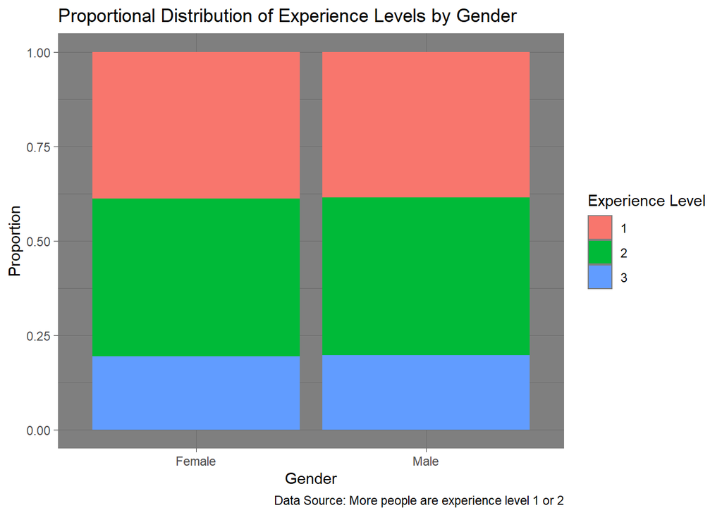

```r
df %>%
    ggplot() +
    geom_bar(mapping = aes(x = Gender, fill = Experience_Level),
             position = 'fill') +
    theme_dark() +
    labs(
        title = "Proportional Distribution of Experience Levels by Gender",
        x = "Gender",
        y = "Proportion",
        fill = "Experience Level",
        caption = "Data Source: More people are experience level 1 or 2"
    )
```

7. Make a plot using combo filter + ggplot

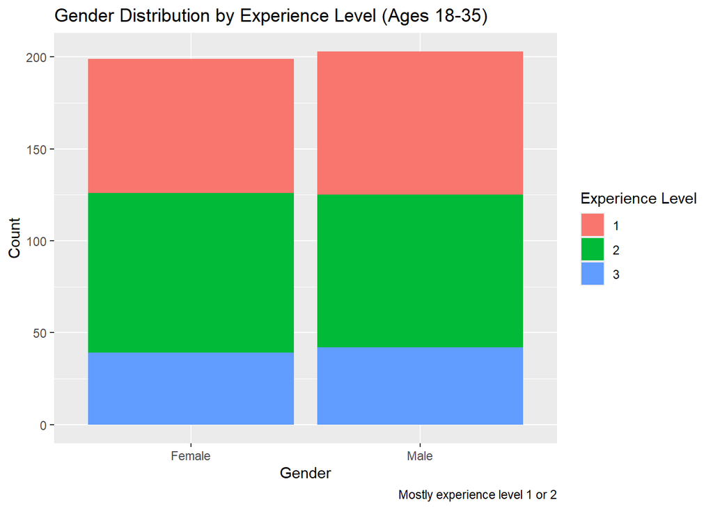

```r
df %>%
    filter(Age>=18, Age<=35) %>%
    ggplot()+
    geom_bar(mapping=aes(x=Gender, fill=Experience_Level)) +
    labs(
        title = "Gender Distribution by Experience Level (Ages 18-35)",
        x = "Gender",
        y = "Count",
        fill = "Experience Level",
        caption = "Mostly experience level 1 or 2")
```